# Your Digest for Sunday, Aug 06, 2023 11:59 PM

# Pulmonary emoblism

#2022SBR Q16

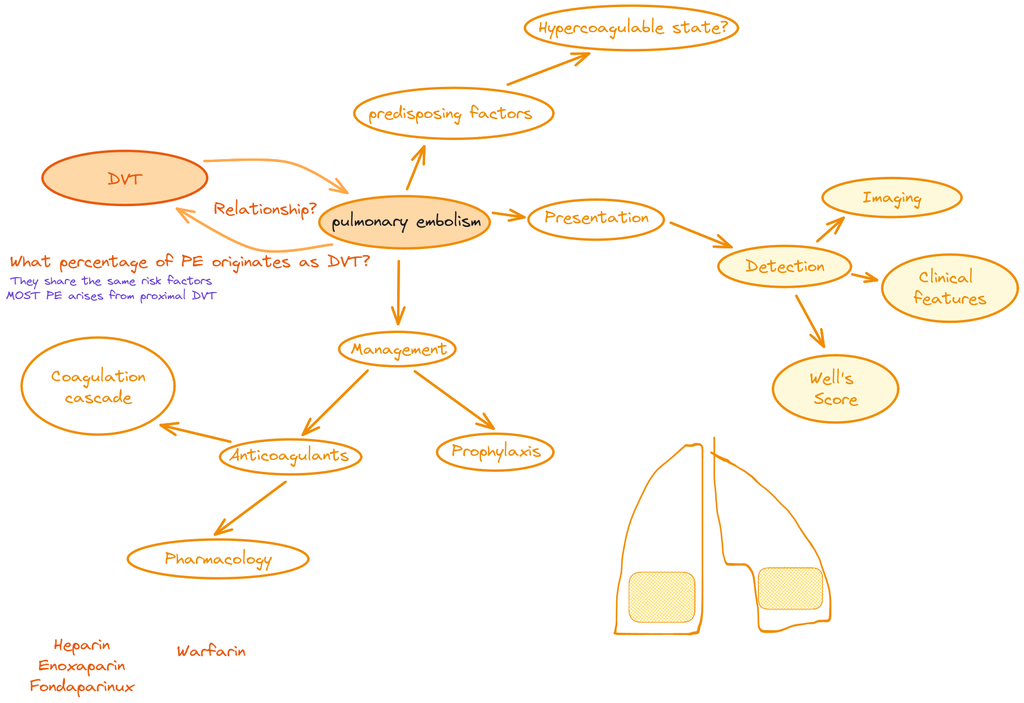

Obstruction of the pulmonary artery of one of it's branches with thrombus, tumour, air, fat etc.

We'll focus on thromboembolism induced PE.

## Pathogenesis of pulmonary embolism

**Most PE arises from proximal DVT of the lower limbs.**  
**Risk factors are the same.**  
Pulmonary emboli are usually multiple, most affecting the lower lobes.

Pulmonary emboli have the following effects of haemodynamics and gas exchange:

- Two mechanisms cause **hypoxia** and respiratory alkalosis;
  - about 10% have small emboli that lodge distally causing infarction -> inflammation -> pleuritic chest pain + haemoptysis
  - Local inflammation -> surfactant dysfunction -> atelectasis -> intrapulmonary shunting
  - Obstruction of vessels -> decreased local perfusion of lung tissue
  - hypoxia and inflammation -> increased respiratory drive -> **hypocapnea** and **respiratory alkalosis**.
- Haemodynamics - increased pulmonary circulation resistance -> increases RV afterload -> RV strain -> RV failure + RV dilation -> decreased LV filling. (IVS bowing and decreased RV output) -> hypotension
  - Normally, multiple large thrombi are required to significantly increase pulmonary pressure and cause RV failure, unless the patient has preexisting cardio / pulmonary disease.
  - *Fluid administration during resuscitation (must be limited) and intubation (ideally avoid) can further compromise RV function.*
  - PE can be classified based on haemodynamic effect: [[#Classification of PE]]

## Classification of PE

Pulmonary embolism can be classified based on several criteria:

- Haemodynamic effect -
  - Haemodyanically unstable PE = hypotension present; (aka. **massive**)
  - Haemodynamically stable
    - **submassive / intermediate risk** - RV strain.
    - **low risk** - no RV strain
- Progression of symptoms
  - Acute - immediate onset of symptoms
  - Subacute - patient presents within days or weeks
  - Chronic - Patient slowly develops pulmonary hypertension (CTEPH)
- Anatomic location
  - 3-6% saddle
  - **Small thrombi in the peripheral segmental / subsegmental branches are more likely to cause pulmonary infarction**. *Inflammation* -> pleuritic pain.
- Symptomatic / asymptomatic
  - Asymptomatic means incidental finding on radiography.

## Presentation of PE

> The most common presenting symptom is **dyspnea followed by chest pain** (classically pleuritic in nature, but not always), cough, and symptoms of deep venous thrombosis. Hemoptysis is an unusual presenting symptom. With severe PE, patients can present with shock, arrhythmia, or syncope. Many patients are **asymptomatic; high index of suspicion is needed**.

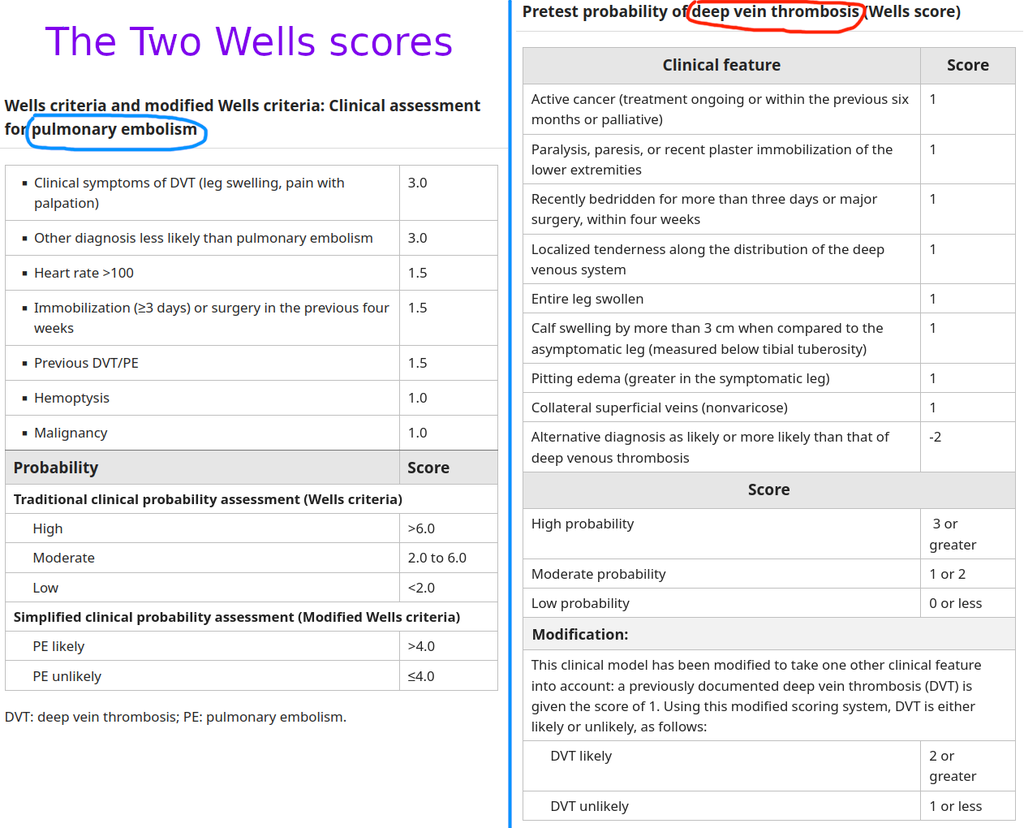

## Treatment

Mainstay is anticoagulation.  
Thrombolysis / embolectomy / IVC filter is reserved for PE with life threatening hypotension.

Haemodynamically unstable -> thrombolysis (if thrombolysis is contraindicated, embolectomy)  
Haemodynamically stable and low risk -> anticoagulation.  
Haemodynamically stable and intermediate risk -> angicoagulation

### Selection of anticoagulant agent

> [!TIP] mnemonic for best anticoagulant in special situations  
> **L**iver failure -> **L**MWH  
> **K**idney failure -> V**K**A  
> Pregnancy = **M**other -> L**M**WH

[figure not shown]

## Long term outcomes

Commonest early complication is recurrence; risk is reduced by anticoagulation.  
Commonest late complication is CTEPH.  
Bleeding from anticoagulation.

# Management of TIA / ischemic stroke

#2022SBR Q21

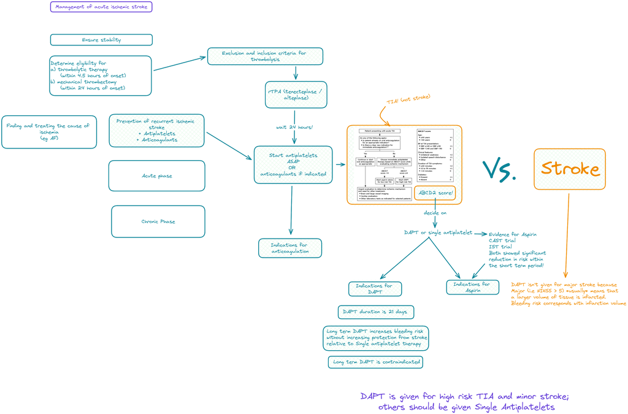

# Urinalysis

[Source](https://labpedia.net/urine-microscopic-examination-and-interpretations-part-2/#Casts)

## Casts

Represents protein precipitated in the distal convoluted tubules.  
Composed of *Tamm-Horsfall protein* which is made by the renal tubular epithelium.

- **Hyaline casts** - only tamm horsfall protein; least significant type of cast.
- **Granular casts** - consist of cell debris, plasma proteins (fibrinogen, immune complexes). Seen in
  - **Course**, deeply pigmented, *muddy brown* casts are considered characteristic of ATN. a
  - Pyelonephritis
  - Glomerulonephritis
  - Malignant nephrosclerosis
  - *Presence of red cells in the case => **Glomerular injury***.
- Fatty casts / urinary lipids (cholesterol esters) : nephrotic syndrome, mercury poisoning, ethylene glycol poisoning.
- **RBC casts** - *Hallmark* of glomerulonephritis; esp. proliferative glomerulonephritis.
- **WBC casts** - interstitial nephritis, pyelonephritis.
- Tubular epithelial cell casts : ATN, acute interstitial nephritis, proliferative glomerulonephritis.

## Cells in the urine

Normal looking RBCs can be seen in any cause of macroscopic or microscopic haematuria.  
*Dysmorphic* RBCs are suggestive of **glomerular** disease. (esp. acanthocytse - specificity of 98% for glomerulonephritis). RBC **casts** also suggest glomerulonephritis.

**WBCs** - usually associated with bacterial infection; also nephrolithiasis / interstitial nephritis.

# Management of stroke [[Stroke]]

see note.